# 202512_morph_lm

```r
library("geomorph")
library("dplyr")
options(rgl.useNULL=TRUE)
library("rgl")
library("tidyverse")
library("gtools")
library(lubridate)
library(gridExtra)
library(factoextra)
```

```r
library(ggplot2)
library(clustvarsel)
library(mclust)
library(ggpubr)
library(svglite)
```

# Import data file

Dir:“/Volumes/Yinghui/202512-dev-seq-analyses”

```r
df <- readRDS("/Volumes/Yinghui/202603-dev-seq-analysis/data/202510-dev-seq-v6.rds")
#df <- readRDS("D:/202603-dev-seq-analysis/data/202510-dev-seq-v6.rds")
```

```r
# convert the lm to matrix for each file.

specs_list <- df %>%
  group_by(temp, biorep, ind, plane, file) %>%
  group_map(~ {
    id <- .y$file
    # Create a sub-list for this specific identifier
    spec <- list(
      matrix = as.matrix(.x[, c("X", "Y")]),
      metadata = as.list(.y)
    )

    setNames(list(spec), id)
  }) %>%
  flatten()
```

```r
# add lm 13 in the TA plane
specs_list<-add_lm13(specs_list)
```

# Plot setting

```r
palette1 <- c("#343434","#A3CEF1","#3880ba","#224f73","#000000","#CCCAC2","#837D72","#ede7da")
```

#linear measurements

```r
measurement_accumulator <- list()

for (id in names(specs_list)) {

  # 1. Extract components correctly
  spec   <- specs_list[[id]]
  mat    <- spec$matrix
  plane  <- spec$metadata$plane
  ind    <- spec$metadata$ind
  temp <- spec$metadata$temp
  biorep <- spec$metadata$biorep
  file <- spec$metadata$file
  measurer <- spec$metadata$measurer

 # print(file)
  # 2. Initialize a placeholder for this specific iteration's results
  res <- tibble()

 # print(file)
  # 3. Apply custom "Design" logic
  if (plane == "PA") {
    res <- tibble(
      measure_name = c("ALO", "AW", "WAE", "ATCL", "PABW"),
      value = c(ALO_fun(mat), AW_fun(mat), WAE_fun(mat), ATCL_fun(mat), PABW_fun(mat))
    )

  } else if (plane == "TA") {
    res <- tibble(
      measure_name = c("PL", "BL", "TCL", "LTM", "LL", "TABW", "AECL","TATB"),
      value = c(PL_fun(mat), BL_fun(mat), TCL_fun(mat), LTM_fun(mat),
                LL_fun(mat), TABW_fun(mat), AECL_fun(mat), TATB_fun(mat))
    )

  } else if (plane == "OA") {
    res <- tibble(
      measure_name = c("TBL", "PW", "ATAC", "AEAC"),
      value = c(TBL_fun(mat), PW_fun(mat), ATAC_fun(mat), AEAC_fun(mat))
    )
  }

  # print(file)
  # print(row(mat))
  # print(file)
  # 4. Add metadata and store in accumulator
  # Only add if we actually generated results
  if (nrow(res) > 0) {
    measurement_accumulator[[id]] <- res %>%
      mutate(
        measurer = measurer,
        sample_id = str_extract(basename(file), "^\\d+"),
        ind = ind,
        plane = plane,
        temp = temp,
        biorep = biorep
      )
  }
}
# 5. Bind into one large dataframe
df_lm <- bind_rows(measurement_accumulator)

df_lm <- df_lm %>% mutate(
    # Convert from microns (or current unit) to mm
    value = value / 1000
  )
```

Removing the value of lobate and auricle when those structures are not present standard: ALO 0.07mm AW 0.07mm LTM 0.07mm LL 0.07mm

```r
threshold <- 0.07

df_lm <- df_lm %>% mutate(across(
    c(value),
    ~ if_else(measure_name %in% c("ALO", "AW", "LTM", "LL") & .x < threshold, NA_real_, .x)
  ))
```

convert the sample_id to date

```r
# Your sample data
date_strings <- df_lm$sample_id

# 1. Convert to Date objects (assuming the year 2026)
# We use parse_date_time to handle the MMDD format
dates <- parse_date_time(paste0(date_strings, "2026"), orders = "mdy")

# 2. Define your starting date (the first date in your list)
start_date <- dates[1]

# 3. Calculate days elapsed
days_diff <- as.numeric(difftime(dates, start_date, units = "days"))

# Results
df <- data.frame(
  Original = date_strings,
  Formatted_Date = dates,
  Days_Since_Start = days_diff
)

print(df)
```

```
##      Original Formatted_Date Days_Since_Start
## 1        1022     2026-10-22                0
## 2        1022     2026-10-22                0
## 3        1022     2026-10-22                0
## 4        1022     2026-10-22                0
## 5        1024     2026-10-24                2
## 6        1024     2026-10-24                2
## 7        1024     2026-10-24                2
## 8        1024     2026-10-24                2
## 9        1026     2026-10-26                4
## 10       1026     2026-10-26                4
## 11       1026     2026-10-26                4
## 12       1026     2026-10-26                4
## 13       1027     2026-10-27                5
## 14       1027     2026-10-27                5
```

[output cut: 5960 more lines]

```r
df_lm$exp_day <- df$Days_Since_Start
```

change the sample id to individual

```r
df_lm <- df_lm  %>%
  mutate(sample_id = paste(ind, temp, biorep, sep = "-"))
```

## allometric dev visualisation

### obtain the natural log of the value

Common practice when studying allometric development because it is easier to deal with proportional variation.

```r
#create a new column with log value
df_lm <- df_lm %>% mutate(log_value = log(value))
```

### plot allometric dev

Using body length as the x axis only focusing on the 20C group

```r
df_lmw <- df_lm %>%
  dplyr::select(-c(plane, log_value)) %>%
  group_by(sample_id, ind) %>%
  pivot_wider(
    names_from = measure_name,
    values_from = value
  ) %>%
  # Filter to only rows where temp is 20
  filter(temp == 20)
```

plot all measurements together

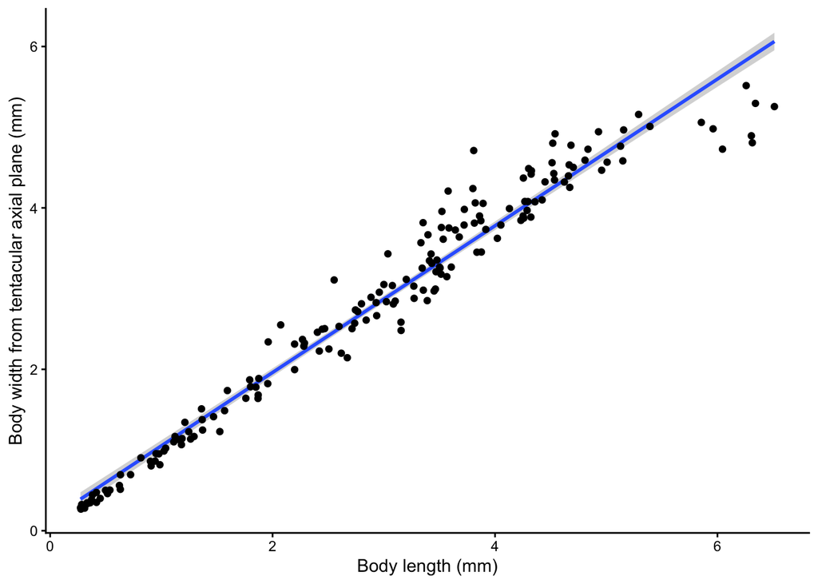

```r
p1 <- ggplot(df_lmw, aes(x = BL, y = TABW)) +
  geom_smooth(method = "lm", linewidth = 1) +
  geom_point()+
  theme_classic() +
  labs(x = "Body length (mm)",
      y = "Body width from tentacular axial plane (mm)")
p1
```

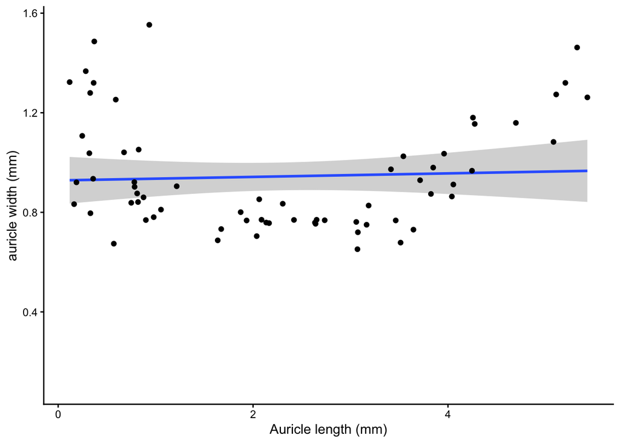

```r
p2 <- ggplot(df_lmw, aes(x = ALO, y = AW)) +
  geom_smooth(method = "lm", linewidth = 1) +
  geom_point()+
  theme_classic() +
  labs(x = "Auricle length (mm)",
      y = "auricle width (mm)")
p2
```

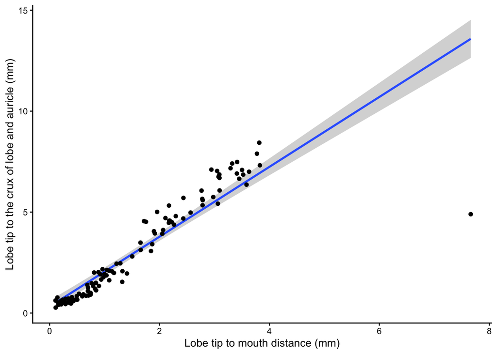

```r
p3 <- ggplot(df_lmw, aes(x = LTM, y = LL)) +
  geom_smooth(method = "lm", linewidth = 1) +
  geom_point()+
  theme_classic() +
  labs(x = "Lobe tip to mouth distance (mm)",
      y = "Lobe tip to the crux of lobe and auricle (mm)")
p3
```

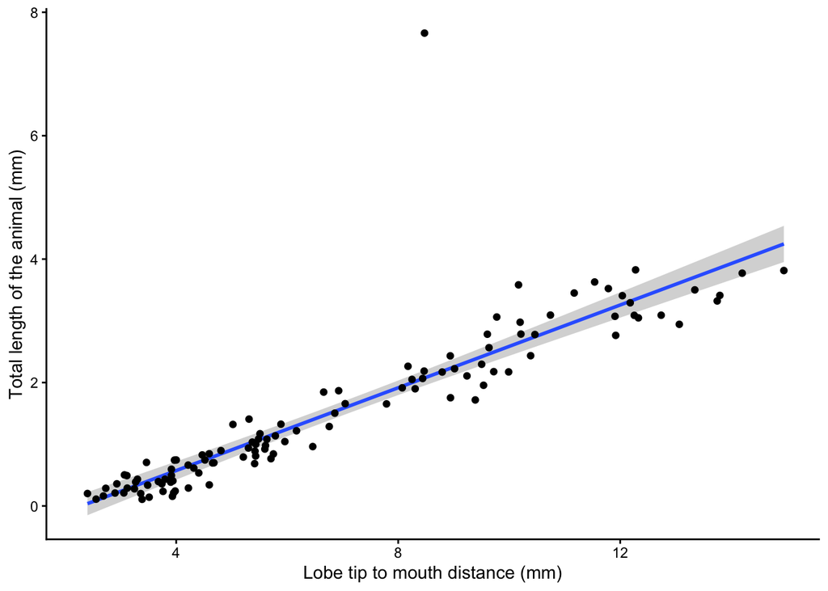

```r
df_lmw$TTL <- df_lmw$LL+df_lmw$BL
p4 <- ggplot(df_lmw, aes(x = TTL, y = LTM)) +
  geom_smooth(method = "lm", linewidth = 1) +
  geom_point()+
  theme_classic() +
  labs(x = "Lobe tip to mouth distance (mm)",
      y = "Total length of the animal (mm)")
p4
```

```r
#shape_nolog<-ggarrange(p1, p2, p3, p4, ncol = 2, nrow = 2)
#ggsave(file="D:/202603-dev-seq-analysis/fig/shape_nolog.svg",width=10, height=8, plot=shape_nolog)
```

### Piece wise regression

```r
library("segmented")
```

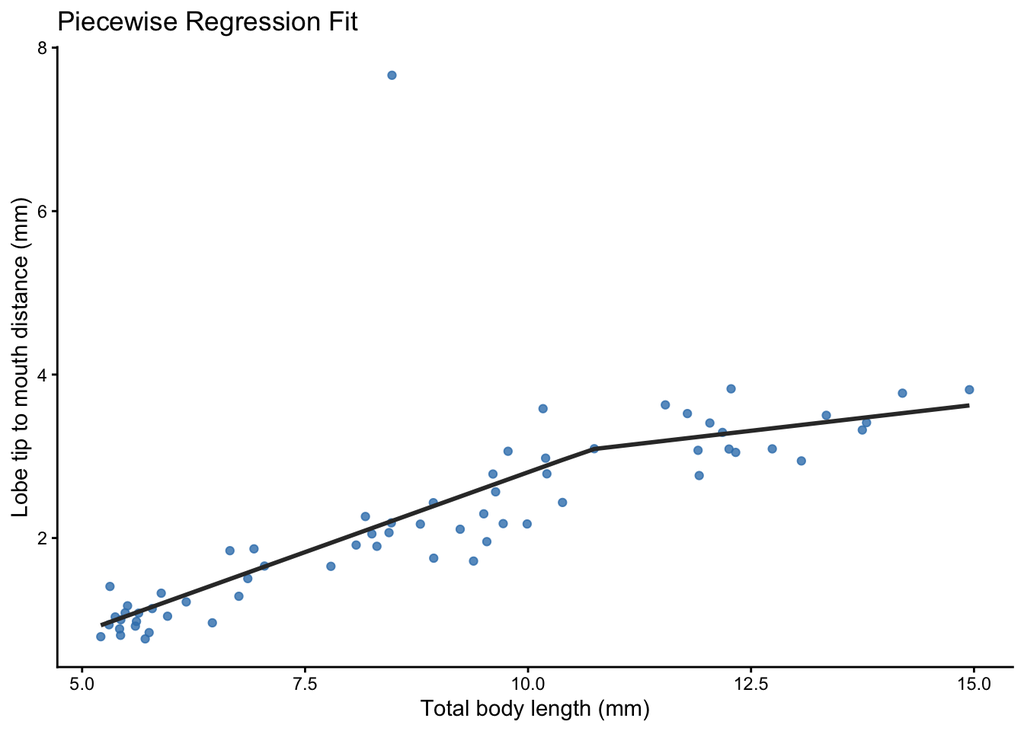

```r
df_clean <- na.omit(df_lmw[, c("BL", "TABW", "ALO","AW","LTM","LL","TTL")])
model1 <- lm(TABW ~ BL, data = df_clean)
model2 <- lm(AW ~ ALO, data = df_clean)
model3 <- lm(LL ~ LTM, data = df_clean)
model4 <- lm(LTM ~ TTL, data = df_clean)

segmented_model1 <- segmented(model1, seg.Z = ~BL)
segmented_model2 <- segmented(model2, seg.Z = ~ALO)
segmented_model3 <- segmented(model3, seg.Z = ~LTM)
segmented_model4 <- segmented(model4, seg.Z = ~TTL)

df_clean$seg_preds1 <- predict(segmented_model1)
df_clean$seg_preds2 <- predict(segmented_model2)
df_clean$seg_preds3 <- predict(segmented_model3)
df_clean$seg_preds4 <- predict(segmented_model4)

pp1 <- ggplot(df_clean, aes(x = BL, y = TABW)) +
  geom_point(color = "#3880ba", alpha = 0.8) +                # Scatter plot of raw data
  geom_line(aes(y = seg_preds1), color = "#343434", size = 1) + # Piecewise regression line
  labs(
    title = "Piecewise Regression Fit",
    x = "Body length (mm)",
    y = "Body width (mm)"
  ) +
  theme_classic()
pp2 <- ggplot(df_clean, aes(x = ALO, y = AW)) +
  geom_point(color = "#3880ba", alpha = 0.8) +                # Scatter plot of raw data
  geom_line(aes(y = seg_preds2), color = "#343434", size = 1) + # Piecewise regression line
  labs(
    title = "Piecewise Regression Fit",
    x = "Auricle length (mm)",
    y = "Auricle width (mm)"
  ) +
  theme_classic()

pp3 <- ggplot(df_clean, aes(x = LTM, y = LL)) +
  geom_point(color = "#3880ba", alpha = 0.8) +                # Scatter plot of raw data
  geom_line(aes(y = seg_preds3), color = "#343434", size = 1) + # Piecewise regression line
  labs(
    title = "Piecewise Regression Fit",
    x = "Lobe tip to mouth distance (mm)",
    y = "Lobe tip to the crux of lobe and auricle (mm)"
  ) +
  theme_classic()


pp4 <- ggplot(df_clean, aes(x = TTL, y = LTM)) +
  geom_point(color = "#3880ba", alpha = 0.8) +                # Scatter plot of raw data
  geom_line(aes(y = seg_preds4), color = "#343434", size = 1) + # Piecewise regression line
  labs(
    title = "Piecewise Regression Fit",
    x = "Total body length (mm)",
    y = "Lobe tip to mouth distance (mm)"
  ) +
  theme_classic()
pp4
```

```r
shape_piecereg<-ggarrange(pp1, pp2, pp3, pp4, ncol = 2, nrow = 2)
#ggsave(file="D:/202603-dev-seq-analysis/fig/shape_piecereg.svg",width=10, height=8, plot=shape_piecereg)
```

## Standardization and then study allometric development

### plot allometric dev

Using body length as the x axis

```r
df_lm20 <- df_lm %>%
  # Filter to only rows where temp is 20
  filter(temp == 20)

df_BL <- df_lm %>%
  # 1. Create a lookup of just the BL values
  left_join(
    df_lm20 %>%
      filter(measure_name == "BL") %>%
      dplyr::select(sample_id, ind, exp_day, bl_value = value, bl_log = log_value),
    by = c("sample_id","ind", "exp_day")
  ) %>%
  filter(!(measure_name %in% c("BL")))

df_TABW <- df_lm %>%
  # 1. Create a lookup of just the BL values
  left_join(
    df_lm20 %>%
      filter(measure_name == "TABW") %>%
      dplyr::select(sample_id, ind, exp_day, bw_value = value, bw_log = log_value),
    by = c("sample_id","ind", "exp_day")
  ) %>%
  filter(!(measure_name %in% c("TABW")))
 # filter(!(measure_name %in% c("BL","PL","TABW")))
```

plot all measurements together

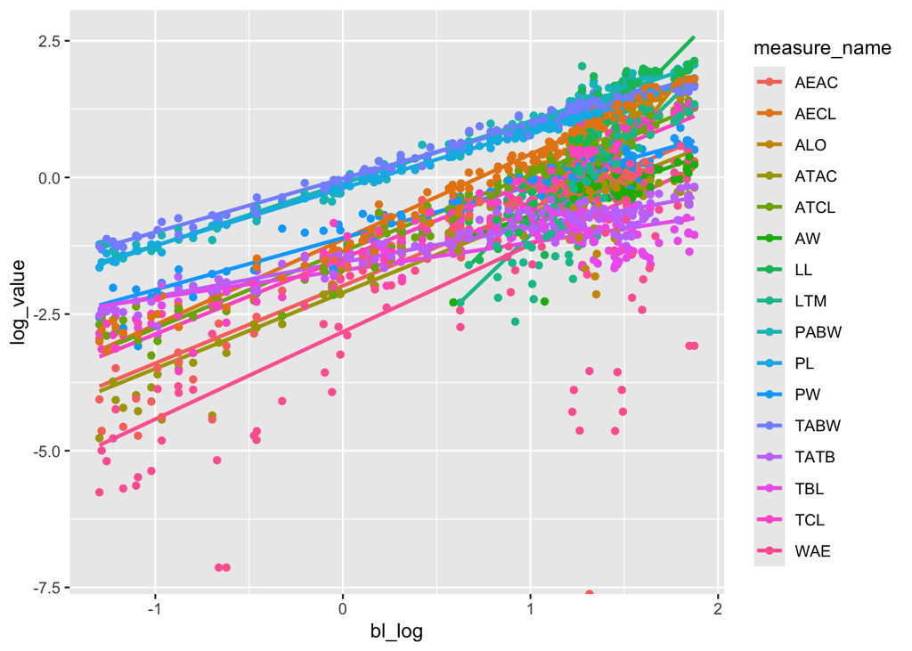

```r
p <- ggplot(df_BL, aes(x = bl_log, y = log_value, color = measure_name)) +
  geom_smooth(method = "lm", se = FALSE, linewidth = 1) +
  geom_point()


p
```

```r
#ggsave("/Volumes/Yinghui/202512-dev-seq-analyses/fig/dev.svg", width=10, height=8)
```

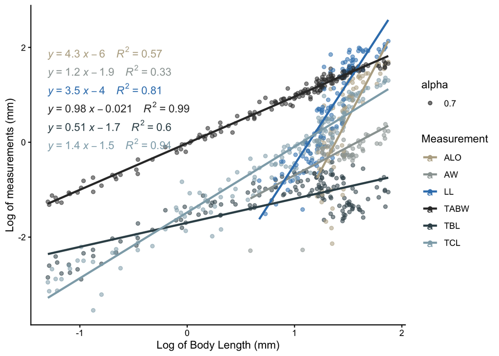

```r
measurement <- c("TABW", "TCL","TBL", "ALO", "AW", "LL")
fig_total <- df_BL %>%
  filter(measure_name %in% measurement) %>% # Only keeps these three
  ggplot(aes(x = bl_log, y = log_value, color = measure_name)) +
  geom_point(aes(alpha = 0.7))+
  geom_smooth(method = "lm", se = FALSE) +
  theme_classic() +scale_color_manual(values = c("TABW" = "#343434", "TCL" = "#8FABB7", "TBL" = "#384F57", "ALO" = "#b8ac92", "AW" = "#9ba3a1", "LL"= "#3880ba"))+ stat_regline_equation(aes(label =  paste(..eq.label.., ..rr.label.., sep = "~~~~")))+labs(
    x = "Log of Body Length (mm)",
    y = "Log of measurements (mm)",
    color = "Measurement"  # Changes the legend title
  )
fig_total
```

```r
ggsave("/Volumes/Yinghui/202603-dev-seq-analysis/fig/dev.svg", fig_total,width=8, height=8)
```

Add equation on the linear regression line on the plot

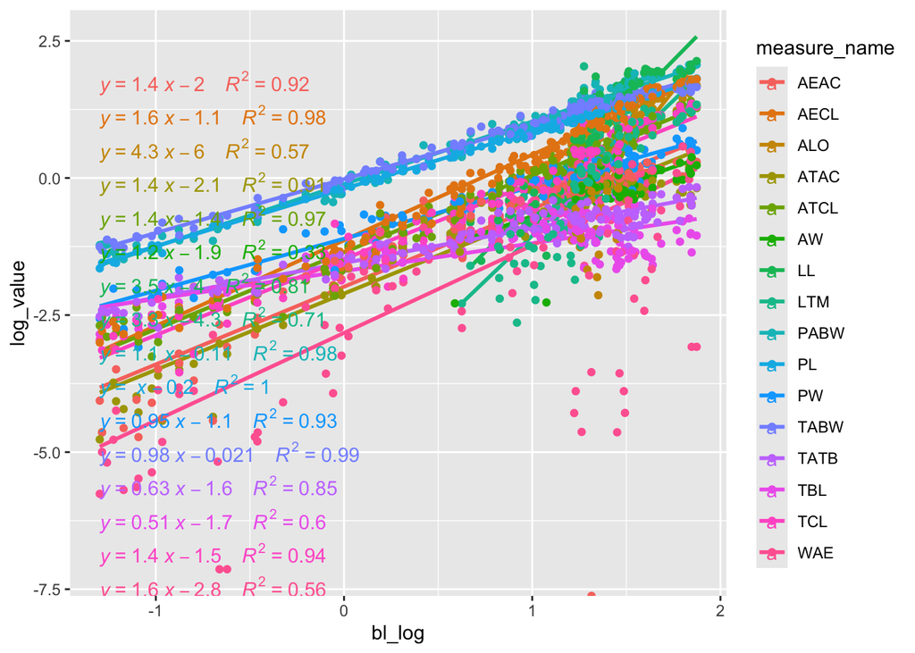

```r
p <- p + stat_regline_equation(aes(label =  paste(..eq.label.., ..rr.label.., sep = "~~~~")))
p
```

```r
df_BL20 <- df_BL %>%
  filter(temp == 20)
```

Group the measurements so that the figure will be clearer. measurements on the aboral plane and related to the canals length

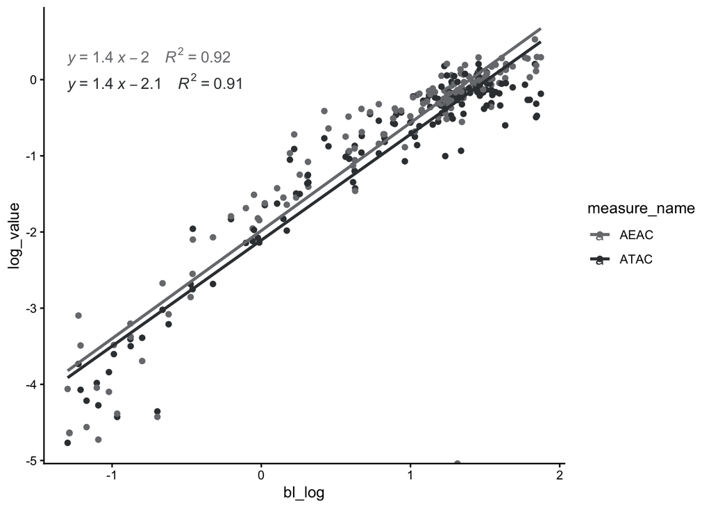

```r
measurement <- c("AEAC","ATAC")
oa <- df_BL20 %>%
  filter(measure_name %in% measurement) %>% # Only keeps these three
  ggplot(aes(x = bl_log, y = log_value, color = measure_name)) +
  geom_point() +
  geom_smooth(method = "lm", se = FALSE) +
  theme_classic() +scale_color_manual(values = c("AEAC" = "#787A7D", "ATAC" = "#393D3F"))+ stat_regline_equation(aes(label =  paste(..eq.label.., ..rr.label.., sep = "~~~~")))
oa
```

measurements of traits that always exist

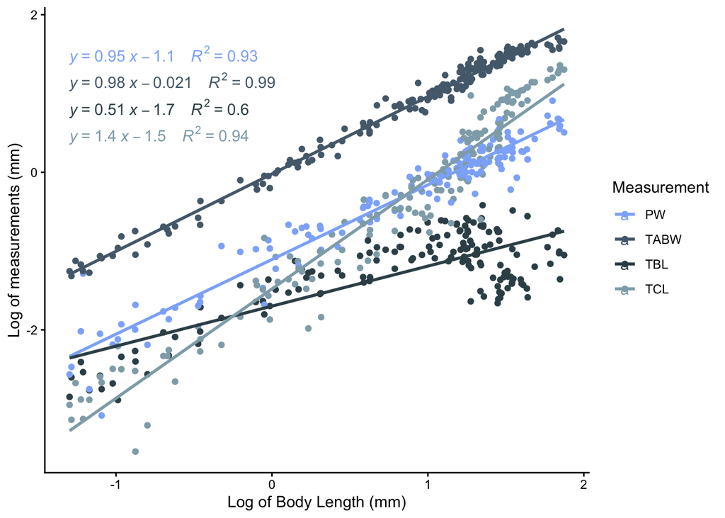

```r
measurement <- c("TABW","TCL","TBL","PW")
fig_total <- df_BL20 %>%
  filter(measure_name %in% measurement) %>% # Only keeps these three
  ggplot(aes(x = bl_log, y = log_value, color = measure_name)) +
  geom_point()+
  geom_smooth(method = "lm", se = FALSE) +
  theme_classic() +scale_color_manual(values = c("TABW" = "#546A7B", "TCL" = "#8FABB7", "TBL" = "#384F57", "PW" = "#8DB2F9"))+ stat_regline_equation(aes(label =  paste(..eq.label.., ..rr.label.., sep = "~~~~")))+labs(
    x = "Log of Body Length (mm)",
    y = "Log of measurements (mm)",
    color = "Measurement"  # Changes the legend title
  )
fig_total
```

measurements related to the lobes

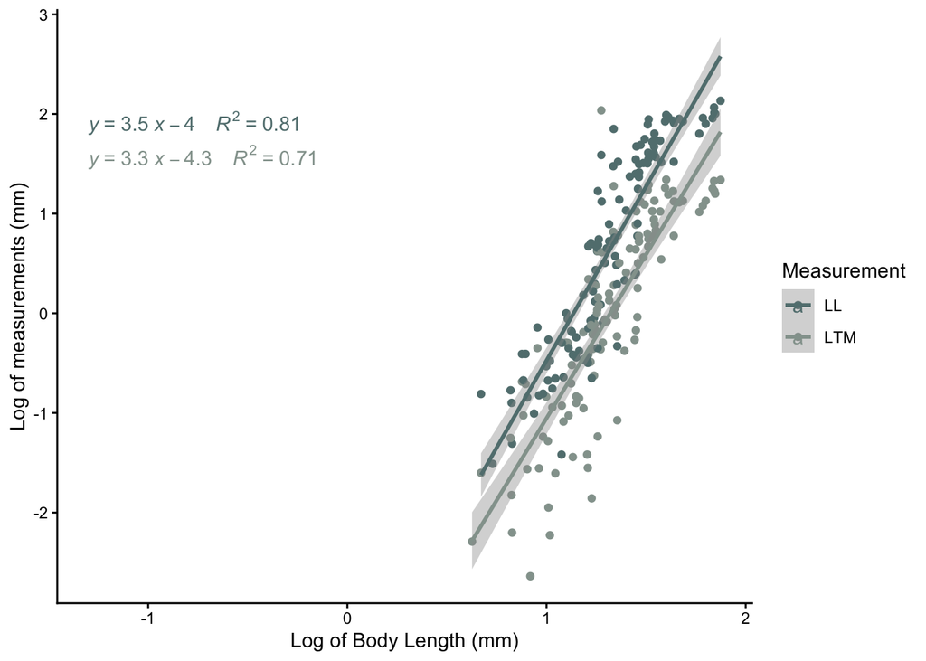

```r
measurement <- c("LL","LTM")
fig_lobe <- df_BL20 %>%
  filter(measure_name %in% measurement) %>% # Only keeps these three
  ggplot(aes(x = bl_log, y = log_value, color = measure_name)) +
  geom_point() +
  geom_smooth(method="lm") +
  theme_classic() +scale_color_manual(values = c("LL" = "#627F7F", "LTM" = "#94A29C"))+
stat_regline_equation(aes(label =  paste(..eq.label.., ..rr.label.., sep = "~~~~")))+labs(
    x = "Log of Body Length (mm)",
    y = "Log of measurements (mm)",
    color = "Measurement"  # Changes the legend title
  )

fig_lobe
```

measurements related to the auricles

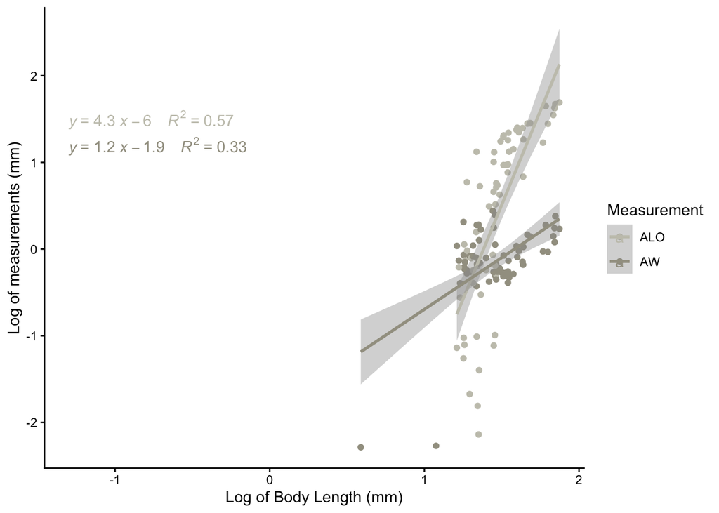

```r
measurement <- c("ALO","AW")
fig_auricle <- df_BL20 %>%
  filter(measure_name %in% measurement) %>% # Only keeps these three
  ggplot(aes(x = bl_log, y = log_value, color = measure_name)) +
  geom_point() +
  geom_smooth(method = "lm") +
  theme_classic() +scale_color_manual(values = c("ALO" = "#C6C5B9", "AW" = "#A29F90")) + stat_regline_equation(aes(label =  paste(..eq.label.., ..rr.label.., sep = "~~~~")))+labs(
    x = "Log of Body Length (mm)",
    y = "Log of measurements (mm)",
    color = "Measurement"  # Changes the legend title
  )

#fig_total
fig_auricle
```

measurement related to ctene row length

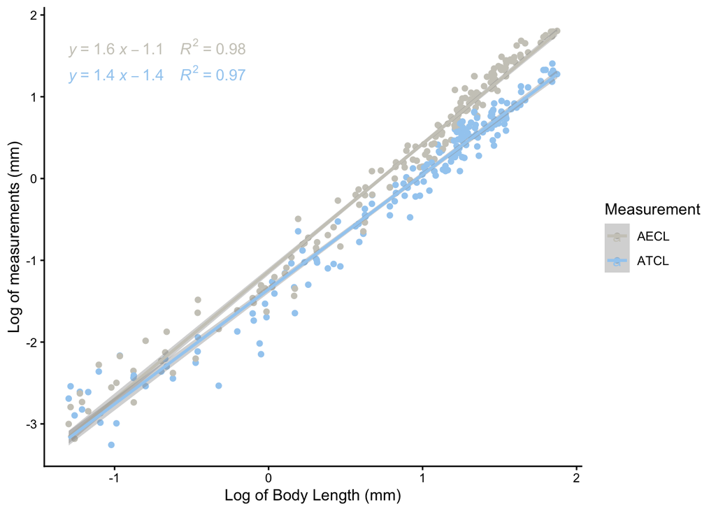

```r
measurement <- c("ATCL","AECL")
fig_cr <- df_BL20 %>%
  filter(measure_name %in% measurement) %>% # Only keeps these three
  ggplot(aes(x = bl_log, y = log_value, color = measure_name)) +
  geom_point() +
  geom_smooth(method = "lm") +
  theme_classic() +scale_color_manual(values = c("ATCL" = "#A3CEF1", "AECL" = "#CCCAC2")) + stat_regline_equation(aes(label =  paste(..eq.label.., ..rr.label.., sep = "~~~~")))+labs(
    x = "Log of Body Length (mm)",
    y = "Log of measurements (mm)",
    color = "Measurement"  # Changes the legend title
  )

#fig_total
fig_cr
```

### plot allometric dev by body width

Using body width as the x axis

```r
df_TABW <- df_lm %>%
  # 1. Create a lookup of just the BL values
  left_join(
    df_lm %>%
      filter(measure_name == "TABW") %>%
      dplyr::select(sample_id, exp_day, bw_value = value, bw_log = log_value),
    by = c("sample_id","exp_day")
  ) %>%
  filter(!(measure_name %in% c("BL")))
 # filter(!(measure_name %in% c("BL","PL","TABW")))

df_TABW20 <- df_TABW %>% filter(temp == 20)
```

plot all measurements together

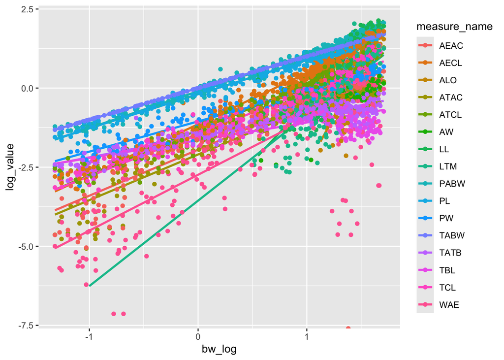

```r
p <- ggplot(df_TABW, aes(x = bw_log, y = log_value, color = measure_name)) +
  geom_smooth(method = "lm", se = FALSE, linewidth = 1) +
  geom_point()


p
```

```r
#ggsave("/Volumes/Yinghui/202512-dev-seq-analyses/fig/dev.svg", width=10, height=8)
```

Group the measurements so that the figure will be clearer. measurements on the aboral plane and related to the canals length

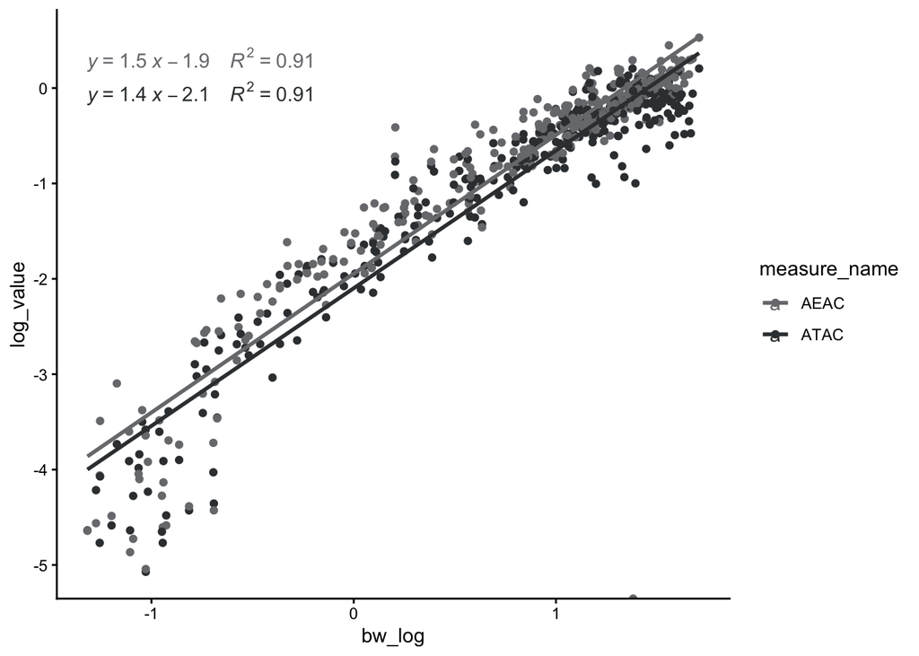

```r
measurement <- c("AEAC","ATAC")
oa <- df_TABW %>%
  filter(measure_name %in% measurement) %>% # Only keeps these three
  ggplot(aes(x = bw_log, y = log_value, color = measure_name)) +
  geom_point() +
  geom_smooth(method = "lm", se = FALSE) +
  theme_classic() +scale_color_manual(values = c("AEAC" = "#787A7D", "ATAC" = "#393D3F"))+ stat_regline_equation(aes(label =  paste(..eq.label.., ..rr.label.., sep = "~~~~")))
oa
```

measurements of traits that always exist

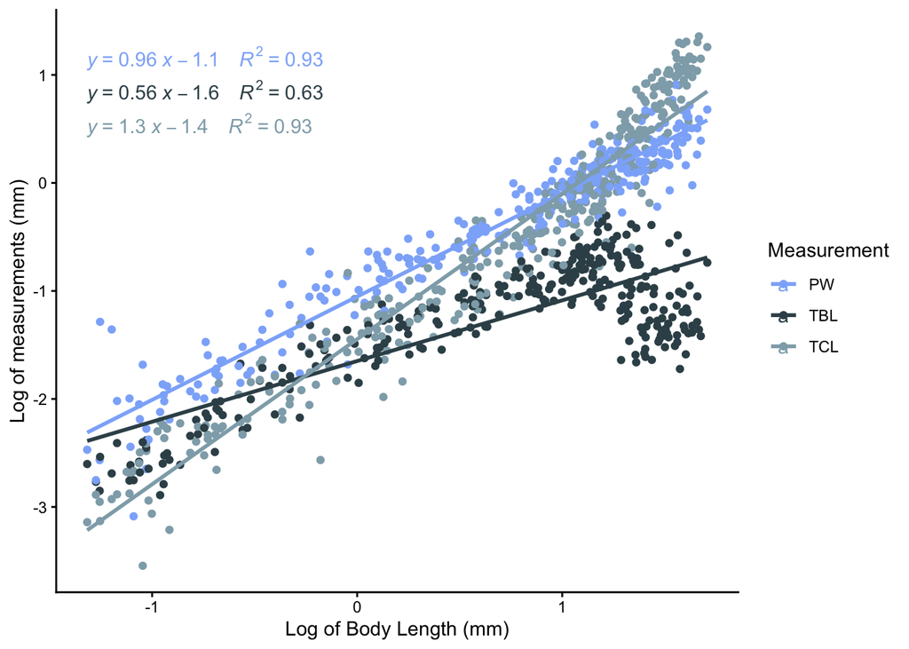

```r
measurement <- c("BL","TCL","TBL","PW")
fig_total <- df_TABW %>%
  filter(measure_name %in% measurement) %>% # Only keeps these three
  ggplot(aes(x = bw_log, y = log_value, color = measure_name)) +
  geom_point()+
  geom_smooth(method = "lm", se = FALSE) +
  theme_classic() +scale_color_manual(values = c("BL" = "#546A7B", "TCL" = "#8FABB7", "TBL" = "#384F57", "PW" = "#8DB2F9"))+ stat_regline_equation(aes(label =  paste(..eq.label.., ..rr.label.., sep = "~~~~")))+labs(
    x = "Log of Body Length (mm)",
    y = "Log of measurements (mm)",
    color = "Measurement"  # Changes the legend title
  )
fig_total
```

measurements related to the lobes

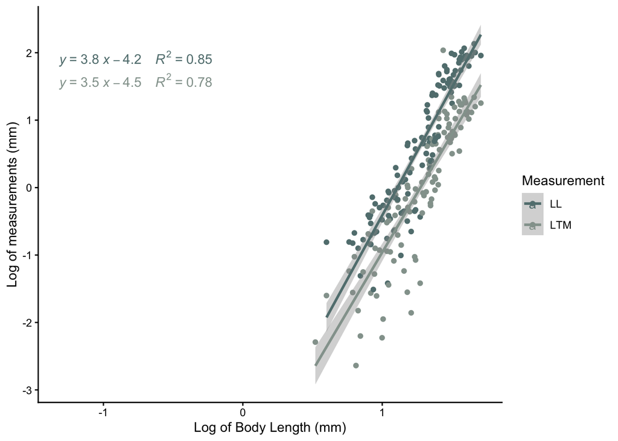

```r
measurement <- c("LL","LTM")
fig_lobe <- df_TABW20 %>%
  filter(measure_name %in% measurement) %>% # Only keeps these three
  ggplot(aes(x = bw_log, y = log_value, color = measure_name)) +
  geom_point() +
  geom_smooth(method="lm") +
  theme_classic() +scale_color_manual(values = c("LL" = "#627F7F", "LTM" = "#94A29C"))+
stat_regline_equation(aes(label =  paste(..eq.label.., ..rr.label.., sep = "~~~~")))+labs(
    x = "Log of Body Length (mm)",
    y = "Log of measurements (mm)",
    color = "Measurement"  # Changes the legend title
  )

fig_lobe
```

measurements related to the auricles

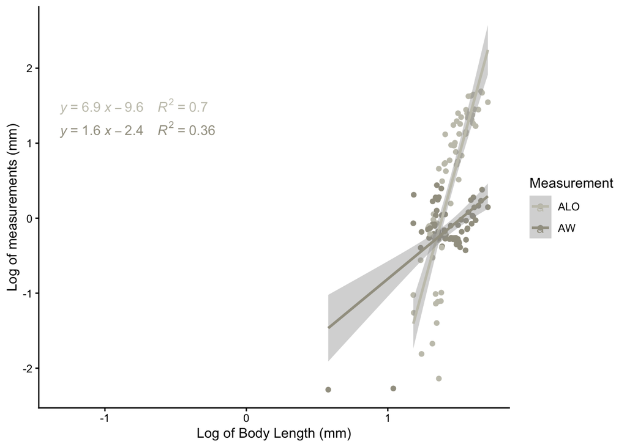

```r
measurement <- c("ALO","AW")
fig_auricle <- df_TABW20 %>%
  filter(measure_name %in% measurement) %>% # Only keeps these three
  ggplot(aes(x = bw_log, y = log_value, color = measure_name)) +
  geom_point() +
  geom_smooth(method = "lm") +
  theme_classic() +scale_color_manual(values = c("ALO" = "#C6C5B9", "AW" = "#A29F90")) + stat_regline_equation(aes(label =  paste(..eq.label.., ..rr.label.., sep = "~~~~")))+labs(
    x = "Log of Body Length (mm)",
    y = "Log of measurements (mm)",
    color = "Measurement"  # Changes the legend title
  )

#fig_total
fig_auricle
```

measurement related to ctene row length

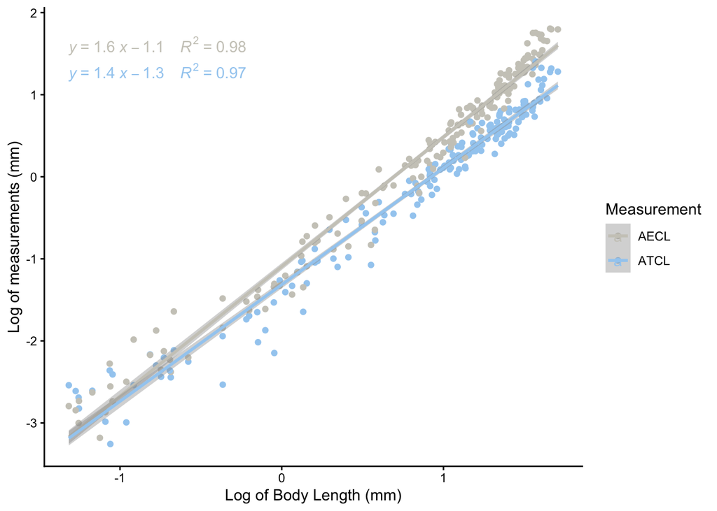

```r
measurement <- c("ATCL","AECL")
fig_cr <- df_TABW20 %>%
  filter(measure_name %in% measurement) %>% # Only keeps these three
  ggplot(aes(x = bw_log, y = log_value, color = measure_name)) +
  geom_point() +
  geom_smooth(method = "lm") +
  theme_classic() +scale_color_manual(values = c("ATCL" = "#A3CEF1", "AECL" = "#CCCAC2")) + stat_regline_equation(aes(label =  paste(..eq.label.., ..rr.label.., sep = "~~~~")))+labs(
    x = "Log of Body Length (mm)",
    y = "Log of measurements (mm)",
    color = "Measurement"  # Changes the legend title
  )

#fig_total
fig_cr
```